# 19K-0305 Assignment#02

## 19K-0305

### Question#01(a):

You are given an unsorted array of 100 elements. All elements are between 1-100 in value and all are distinct except one element that repeats two times. Design O(n2) time algorithm to and the duplicate element in the array.

```python
import numpy as np
import pandas as pd
import random

array = []
for i in range(0,100):
    array.append(i+1)

#printing original array
print(array)

#making any random index a duplicate
x = random.choice(array)
y = random.choice(array)
array[x] = y

print("\nChanging index: ",x," with value: ",y)

#printing array after modification
print(array)

for i in range(len(array)):
    for j in range(i+1,len(array)):
        if array[i] == array[j]:
            print("\n",array[i], "is the duplicate.\n")
            break
```

```
[1, 2, 3, 4, 5, 6, 7, 8, 9, 10, 11, 12, 13, 14, 15, 16, 17, 18, 19, 20, 21, 22, 23, 24, 25, 26, 27, 28, 29, 30, 31, 32, 33, 34, 35, 36, 37, 38, 39, 40, 41, 42, 43, 44, 45, 46, 47, 48, 49, 50, 51, 52, 53, 54, 55, 56, 57, 58, 59, 60, 61, 62, 63, 64, 65, 66, 67, 68, 69, 70, 71, 72, 73, 74, 75, 76, 77, …

Changing index:  7  with value:  20
[1, 2, 3, 4, 5, 6, 7, 20, 9, 10, 11, 12, 13, 14, 15, 16, 17, 18, 19, 20, 21, 22, 23, 24, 25, 26, 27, 28, 29, 30, 31, 32, 33, 34, 35, 36, 37, 38, 39, 40, 41, 42, 43, 44, 45, 46, 47, 48, 49, 50, 51, 52, 53, 54, 55, 56, 57, 58, 59, 60, 61, 62, 63, 64, 65, 66, 67, 68, 69, 70, 71, 72, 73, 74, 75, 76, 77,…

 20 is the duplicate.
```

### Question#01 (b)

Design O(n)time algorithm to find the duplicate element in the array.

```python
import numpy as np
import pandas as pd
import random

array = []
for i in range(0,100):
    array.append(i+1)

#printing original array
print(array)

#making any random index a duplicate
x = random.choice(array)
y = random.choice(array)
array[x] = y

print("\nChanging index: ",x," with value: ",y)

#printing array after modification
print(array)

MaxValue = max(array)

#Declare new array of max size
newArray = [0] * (MaxValue+1)

for index in range(0,MaxValue):
    newArray[array[index]]=newArray[array[index]]+1


for item in range(0,100):
    if(newArray[array[item]]==2):
       print("\n",array[item], "is the duplicate.\n")
       break
```

```
[1, 2, 3, 4, 5, 6, 7, 8, 9, 10, 11, 12, 13, 14, 15, 16, 17, 18, 19, 20, 21, 22, 23, 24, 25, 26, 27, 28, 29, 30, 31, 32, 33, 34, 35, 36, 37, 38, 39, 40, 41, 42, 43, 44, 45, 46, 47, 48, 49, 50, 51, 52, 53, 54, 55, 56, 57, 58, 59, 60, 61, 62, 63, 64, 65, 66, 67, 68, 69, 70, 71, 72, 73, 74, 75, 76, 77, …

Changing index:  76  with value:  65
[1, 2, 3, 4, 5, 6, 7, 8, 9, 10, 11, 12, 13, 14, 15, 16, 17, 18, 19, 20, 21, 22, 23, 24, 25, 26, 27, 28, 29, 30, 31, 32, 33, 34, 35, 36, 37, 38, 39, 40, 41, 42, 43, 44, 45, 46, 47, 48, 49, 50, 51, 52, 53, 54, 55, 56, 57, 58, 59, 60, 61, 62, 63, 64, 65, 66, 67, 68, 69, 70, 71, 72, 73, 74, 75, 76, 65, …

 65 is the duplicate.
```

### Question#02 (a)

You are given an array of positive integers in unsorted arrangement. You need to arrange the array in a zig-zag value of magnitudes such that a[1] > a[2] < a[3] > a[4] < a[5] > a[6] and so on. Design a O(nlogn) algorithm for this problem where n is the length of array.

```python
import numpy as np
import pandas as pd
import random


def mergeSort(array):
    if len(array) > 1:
        mid = len(array)//2

        LeftArray= array[:mid]
        RightArray= array[mid:]
        #applying mergeSort on both LeftArray and RightArray
        mergeSort(LeftArray)
        mergeSort(RightArray)

        i=j=k=0

        while i<len(LeftArray) and j<len(RightArray):
            if(LeftArray[i] < RightArray[j]):
                array[k] = LeftArray[i]
                i=i+1
                k=k+1
            else:
                array[k] = RightArray[j]
                j=j+1
                k=k+1

        while i<len(LeftArray):
            array[k] = LeftArray[i]
            i=i+1
            k=k+1
        while j<len(RightArray):
            array[k] = RightArray[j]
            j=j+1
            k=k+1

#comment bellow 2 lines of codes and uncomment further down lines for dynamic size input
array = [4,6,8,19,2,1,0,3,9,5]

# array = []
# x= int(input("Enter the size of array you want to create: "))
# i=0
# while i<x:
#     val = random.choice(np.array([1,2,3,4,5,6,7,8,9,10,11,12,13,14,15,16,17,18,19,20]))
#     array.append(val)
#     i += 1

print("\nThe original array\n",array)
mergeSort(array)
print("\nThe sorted array\n",array)

for i in range(0,len(array)-1,2):
    array[i],array[i+1]= array[i+1], array[i]
print("\nThe final array in zig-zag form:\n",array)
```

```
The original array
 [4, 6, 8, 19, 2, 1, 0, 3, 9, 5]

The sorted array
 [0, 1, 2, 3, 4, 5, 6, 8, 9, 19]

The final array in zig-zag form:
 [1, 0, 3, 2, 5, 4, 8, 6, 19, 9]
```

### Question#02 (b)

Design O(n) time algorithm or better for this problem.

```python
import numpy as np
import pandas as pd

def CountSort(array):
    MaxValue = max(array)

    #Declare new array of max size
    newArray = [0] * (MaxValue+1)

    for index in range(0,len(array)):
        newArray[array[index]]=newArray[array[index]]+1

    i=j=0
    while(i<MaxValue+1):
        if(newArray[i]>0):
            array[j]=i
            newArray[i] -= 1
            j += 1
        else:
            i += 1

array = [4,6,8,19,2,1,0,3,9,5]
print("\nThe original array\n",array)
CountSort(array)
print("\nThe sorted array\n",array)

for i in range(0,len(array)-1,2):
    array[i],array[i+1]= array[i+1], array[i]
print("\nThe final array in zig-zag form:\n",array)
```

```
The original array
 [4, 6, 8, 19, 2, 1, 0, 3, 9, 5]

The sorted array
 [0, 1, 2, 3, 4, 5, 6, 8, 9, 19]

The final array in zig-zag form:
 [1, 0, 3, 2, 5, 4, 8, 6, 19, 9]
```

### Question#03 (a)

Suppose you want to calculate square of a given number x with out using multiplication *, division / and pow() function. Design algorithm for this problem in O(n) time Design algorithm for this in O(logn) time

```python
import numpy as np
import pandas as pd

x = int(input("Enter a number to calculate the square of: "))
if(x<0):
    x=-x
square = 0

for i in range(1,x+1):
    square += x

print(square)
```

```
Enter a number to calculate the square of: 10
100
```

### Question#03 (b)

Design algorithm for this in O(logn) time

```python
import numpy as np
import pandas as pd


def findSquare(num):
    if num == 0:
        return 0
    if num < 0:
        num = -num

    #find floor value by bitwise right operator (n/2)
    half = num>>1

    if(num%2==0):
        return (findSquare(half) << 2)
    else:
        return (findSquare(half) << 2) + (half << 2) + 1

x = int(input("Enter a number to calculate the square of: "))
if(x<0):
    x=-x
print("The Square of",x,":", findSquare(x))
```

```
Enter a number to calculate the square of: 10
The Square of 10 : 100
```

### Question# 04

You know that divide and conquer algorithm exists to find maximum subarray sum of any given array in O(nlogn) time. Design algorithm for this problem that takes no longer than O(n) time.

```python
import numpy as np
from sys import maxsize

def maxSubArray(array):
    max_total = -maxsize -1
    max_yet = 0
    start = 0
    end = 0
    point =0
    for i in range(0,len(array)):
        max_yet = max_yet + array[i]

        if max_total < max_yet:
            max_total = max_yet
            start = point
            end = i

        if max_yet < 0:
            max_yet = 0
            point = i + 1

    print("The sum of maximum sub array:",max_total)
    print("Starting index:",start, "\nEnding index:",end)
    print("The elements forming the maximum subarray: ", array[start:end+1])

array = [-2, 1,-3,4,-1,2,1,-5,4]
maxSubArray(array)
```

```
The sum of maximum sub array: 6
Starting index: 3
Ending index: 6
The elements forming the maximum subarray:  [4, -1, 2, 1]
```

### Question# 05(a)

(a) You have studied binary search algorithm to search any number in an array. There is another technique of searching known as Jump Search. Learn about Jump search algorithm from this link https://www.geeksforgeeks.org/jump-search/. Take any input sorted array (atleast of size 8) and search a number present at the end of array using both binary search and Jump search. Show each iteration of both algorithms. Discuss pros and cons of both techniques in di erent circumstances.

#### JUMP SEARCH

```python
import numpy as np
import math

def jumpSearch(arr, search):
    step = math.sqrt(len(arr))
    print("\nEach step will be of ", int(step))

    previous = 0
    i=0
    while arr[int(min(step,len(arr))-1)] < search:
        print("\nITERATION #",i)
        previous = step
        print("The new step : ", int(previous))
        step = step + math.sqrt(len(arr))
        print("Next additional step : ", int(previous))
        if(previous > len(arr)):
            return -1
        else:
            print("The search element exists in the right from current step.")
            i=i+1

    while(arr[int(previous)] < search):
        previous = previous+1

        if(arr[int(previous)]==min(step, len(arr))):
            return -1

    if (arr[int(previous)]==search):
        return previous

    return -1


arr  = [ 0, 1, 1, 2, 3, 5, 8, 13, 21,34, 55, 89, 144, 233, 377, 610 ]
search = int(input("Enter the number you want to input : "))

index = int(jumpSearch(arr,search))

if (index == -1):
    print("\nThe element doesn't exist in the array.")
else:
    print("\nElement",search,"FOUND! At index: ",index)
```

```
Enter the number you want to input : 10

Each step will be of  4

ITERATION # 0
The new step :  4
Next additional step :  4
The search element exists in the right from current step.

The element doesn't exist in the array.
```

#### BINARY SEARCH

```python
import numpy as np
import math

def BinarySearch(array,search):
    l=0
    hi=len(array)
    mid=0
    i=0

    while(l<hi):
        print("\nITERATION #",i)
        mid = (l+hi)//2
        print("Low:",l,"High:",hi,"Mid:",mid)
        if(array[mid]==search):
            return mid
        elif(array[mid]>search):
            hi=mid-1
        else:
            l=mid+1
        i=i+1
    return -1

arr  = [ 0, 1, 1, 2, 3, 5, 8, 13, 21,34, 55, 89, 144, 233, 377, 610 ]
search = int(input("Enter the number you want to input : "))

index = int(BinarySearch(arr,search))

if (index == -1):
    print("\nThe element doesn't exist in the array.")
else:
    print("\nElement",search,"FOUND! At index: ",index)
```

```
Enter the number you want to input : 10

ITERATION # 0
Low: 0 High: 16 Mid: 8

ITERATION # 1
Low: 0 High: 7 Mid: 3

ITERATION # 2
Low: 4 High: 7 Mid: 5

ITERATION # 3
Low: 6 High: 7 Mid: 6

The element doesn't exist in the array.
```

### Pros and Cons of JUMP SEARCH

#### Pros:

- It seaches fewer item in the list than the linear search by jumping fixed number of steps.
- The optimal jump searches requires root(n) time to search the element.
- It requires less comparisions than the linear search

#### Cons:

- It only works for sorted input array.
- It takes more time than binary search in cases as log(n) < root(n)
- If the jump steps are larger than the number of comparisions will be very high, so it performs good when jump steps are suitable as compared to the size of the array.
- performs like linear search if array is of small size.

### Pros and Cons of BINARY SEARCH

#### Pros:

- It searches faster than both the linear search and the jump search.
- It takes way less number of comparisions when array is large enough.
- Time complexity of binary search is (logn) which is smaller than both the linear and jump search

#### Cons:

- It's more complicated to code binary search than the linear search.
- It doesn't performs well in smaller arrays as the mid element will not be large enough to divide and search.
- Only works on sorted list.

## Question# 05 (b)

Learn about how interpolation and exponential search works from this link https : ==www:geeksforgeeks:org=searching  algorithms= Write working of both searching algorithms (interpolation and exponential) in your own words.

### Interpolation Search:

interpolation search is just an improvement for the binary search. It is used in the situations where the values in a sorted array are distributed uniformly, that is, the distance between the values are uniform. Interploation search may go to different array indexes depending upon the value it gets from the formula: pos = lo + [ (x-arr[lo])*(hi-lo) / (arr[hi]-arr[Lo]) ]

it search for the position and determines the position/location of the search element. If the key is in starting indexes, the position is most likely to return starting index position and it will search starting indexes. It first checks the position that it has found, if that's the position. It returns that index, if it's less than the position, it checks out new position on left side and right side respectively dependending upon if the value is larger or smaller.

### Exponential Search:

exponential search or doubling search is a searching algorithm for searching infinite/ unbounded lists. The idea behind this search is to find the range where the search element might lie and to perform binary search in that particular range so it performs the search pretty fast. It only works on sorted array. In the first stage, if the list is in ascending order, the code looks for very initial exponent i and the value of 2^j is greater than the search key for which this 2^j becomes the upper bound for the binary search with the previous power of 2^j -1 which becomes the lower bound for the binary search. In the second stage, the binary search is applied on the range.

### Question # 06

HeapSort is a sorting technique that takes O(nlogn) time. You may watch this video to understand working of heap sort. https : ==www:youtube:com=watch?v = MtQLll5KhQ Suppose array A contains 4,1,3,2,16,9,10,14,8,7. Sort it using heap sort along with showing each iteration.

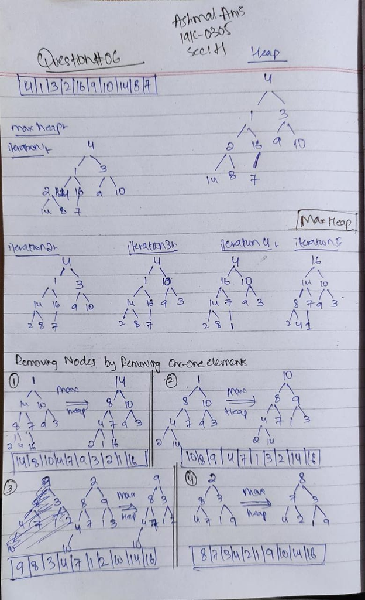

```python
from IPython.display import Image
Image(filename='question6(1).jpg')
```

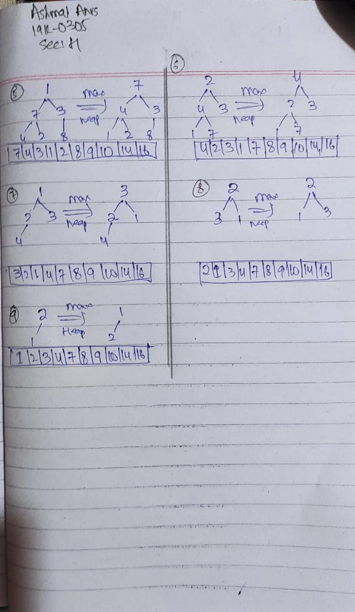

```python
from IPython.display import Image
Image(filename='question6(2).jpg')
```